# rEDM Primer

Hao Ye

2018-11-15

# 1 Abstract

This document is designed to be a quick intro for “empiricial dynamic modeling” (EDM) and the **rEDM** package. For more detailed information, please see the `rEDM-tutorial` vignette include in the package [[link]](https://cran.r-project.org/web/packages/rEDM/vignettes/rEDM-tutorial.html).

# 2 Theory

Suppose that we have a system with $d$ state variables: $x_1, x_2, \dots, x_d$. We can represent the state at a specific time, $t$, as a vector with these $d$ components: $\bar{x}(t) = \langle x_1(t), x_2(t), \dots, x_d(t) \rangle$.

We generally assume that the system is deterministic, such that the current state fully determines future states:
$$\bar{x}(t+1) = F \left(\bar{x}(t)\right)$$
though we may not know what this function $F$ actually is.

## 2.1 Example

In model systems, we usually know what $F$ is, since we have differential or difference equations that describe the system behavior. For example, the coupled logistic map equations are:
$$\begin{align*}
x_1(t+1) &= r_1 x_1(t) \left[1 - x_1(t) - \alpha_{1,2} x_2(t)\right]\\
x_2(t+1) &= r_2 x_2(t) \left[1 - x_2(t) - \alpha_{2,1} x_1(t)\right]
\end{align*}$$
with parameters $r_1, r_2, \alpha_{1,2}, \alpha_{2,1}$.

## 2.2 Time Delay Embedding (Delay Coordinate Embedding)

We would naturally expect that to predict the future of any component of the system, e.g. $x_i$, we would need to know all the other $x_j$ values. Takens’ Theorem actually posits that this is not strictly necessary, and that under certain conditions, a single time series is sufficient.

In other words, instead of relying on:
$$x_i(t+1) = F_i\left(x_1(t), x_2(t), \dots, x_d(t)\right)$$

the system dynamics can be represented as a function of a single variable and its lags:
$$x_i(t+1) = G_i\left(x_i(t), x_i(t-1), \dots, x_i(t-(E-1))\right)$$

Note that we use $E$ coordinates instead of $d$ and that we do not make any claims about how the functions $F_i$ and $G_i$ are related.

## 2.3 Usage

Since we generally don’t know the form of $G_i$, we stick to inferring it from the data. The **rEDM** package provides several methods to do so, but here we just stick to simplex projection.

Simplex projection uses a weighted nearest-neighbors approximation to estimate $G_i$. That’s kind of a fancy way of saying the following:

1. Suppose we have the value of $x$ and its lags at time $s$. Then we want a prediction of $x(s+1) = G\left(x(s), x(s-1), \dots, x(s - (E-1))\right)$.
2. We look for $j = 1..k$ nearest neighbors in the observed time series of $x$ such that $\langle x(s), x(s-1), \dots, x(s - (E-1))\rangle \approx \langle x(n_j), x(n_j-1), \dots, x(n_j - (E-1))\rangle$.
3. We then suppose that $x(s+1) \approx x(n_j+1)$.

Mathematically, this occurs by using some distance function to judge how similar $\langle x(s), x(s-1), \dots, x(s - (E-1))\rangle$ is to $\langle x(n_j), x(n_j-1), \dots, x(n_j - (E-1))\rangle$ and estimating $x(s+1)$ as a weighted average of the $x(n_j+1)$ values with weighting determined by the distances.

# 3 Applications

These principles of EDM can be used for several different applications. These include:

- univariate forecasting (predicting future behavior using lags of a single time series)
- multivariate forecasting (predicting future behavior using lags of multiple time series)
- characterizing various properties of time series (e.g. predictability and “nonlinearity”)
- identifying causal relationships between time series

Here, we’ll just look at univariate forecasting, though there are examples for the others among the package documentation. (see the vignettes on [CRAN](https://cran.r-project.org/web/packages/rEDM/index.html))

# 4 Univariate Forecasting

## 4.1 Data

We’ll start by looking at sunspot data. Note that there is also monthly data, but it seems quite a bit noisier:

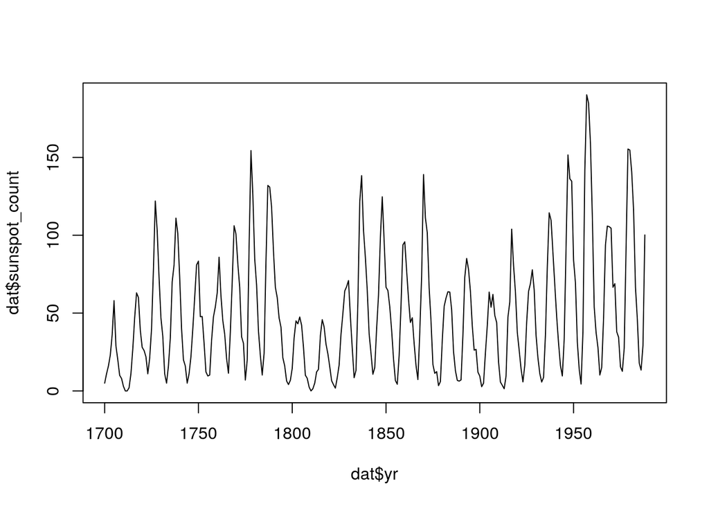

```r
dat <- data.frame(yr = as.numeric(time(sunspot.year)),
                  sunspot_count = as.numeric(sunspot.year))

plot(dat$yr, dat$sunspot_count, type = "l")
```

## 4.2 Determining E

From the above sections, you may recall that one of the parameters is the embedding dimension, `E`. Since we ultimately want to test forecast skill, we use only the first 2/3 of the data to fit `E`. There are several other parameters that we can set, but the defaults work fine for our case:

```r
library(rEDM)                    # load the package

n <- NROW(dat)
lib <- c(1, floor(2/3 * n))      # indices for the first 2/3 of the time series
pred <- c(floor(2/3 * n) + 1, n) # indices for the final 1/3 of the time series

simplex(dat,                     # input data (for data.frames, uses 2nd column)
        lib = lib, pred = lib,   # which portions of the data to train and predict
        E = 1:10)                # embedding dimensions to try
```

```
##     E tau tp nn num_pred       rho      mae     rmse perc         p_val
## 1   1   1  1  2      191 0.6991334 19.02584 26.30722    1  8.621117e-33
## 2   2   1  1  3      190 0.9074985 10.73279 14.73790    1  2.037040e-95
## 3   3   1  1  4      189 0.9195079 10.16759 13.93505    1 4.910681e-104
## 4   4   1  1  5      188 0.9195163 10.46335 14.00166    1 1.703957e-103
## 5   5   1  1  6      187 0.9176281 10.92784 14.17733    1 2.032115e-101
## 6   6   1  1  7      186 0.9160703 11.21311 14.28820    1  1.170578e-99
## 7   7   1  1  8      185 0.9082384 11.42164 14.98126    1  1.974748e-93
## 8   8   1  1  9      184 0.8911547 11.98804 16.38659    1  1.675719e-82
## 9   9   1  1 10      183 0.8708673 12.95866 17.75854    1  3.249362e-72
## 10 10   1  1 11      182 0.8561815 13.38768 18.57338    1  6.248548e-66
##    const_pred_num_pred const_pred_rho const_pred_mae const_pred_rmse
## 1                  191      0.8181284       16.30681        21.10918
## 2                  190      0.8171769       16.36105        21.16018
## 3                  189      0.8164772       16.42116        21.21297
```

[output cut: 18 more lines]

The output is a data.frame describing how well the model “predicted” on the given data. The columns are various statistical outputs. We’ll focus just on the measures of model performance:

- rho (correlation between observed and predicted values)
- mae (mean absolute error)
- rmse (root mean squared error)

It looks like `E = 3` or `4` is optimal. Since we generally want a simpler model, if possible, let’s go with `E = 3` to forecast the remaining 1/3 of the data.

## 4.3 Forecasts

We can use similar code to produce forecasts for the last 1/3 of the time series. Since we want the outputs in addition to the performance statistics, we add an additional argument to the function call:

```r
output <- simplex(dat,
        lib = lib, pred = pred,  # predict on last 1/3
        E = 3,
        stats_only = FALSE)      # return predictions, too
```

Here the output is again a data.frame with a list column for the predictions:

```r
predictions <- output$model_output[[1]]
str(predictions)
```

```
## 'data.frame':    97 obs. of  4 variables:
##  $ time    : num  1893 1894 1895 1896 1897 ...
##  $ obs     : num  85.1 78 64 41.8 26.2 26.7 12.1 9.5 2.7 5 ...
##  $ pred    : num  NaN NaN 49.3 45 36.2 ...
##  $ pred_var: num  NaN NaN 24 40.6 88.2 ...
```

Let’s plot the predictions against the original data:

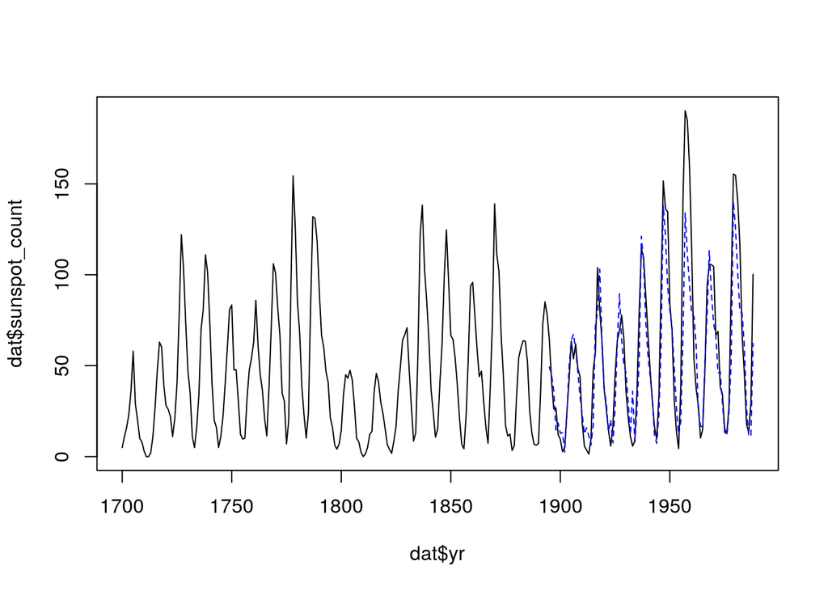

```r
plot(dat$yr, dat$sunspot_count, type = "l")
lines(predictions$time, predictions$pred, col = "blue", lty = 2)
```

Since we also have an estimate of the prediction uncertainty, let’s include that as well:

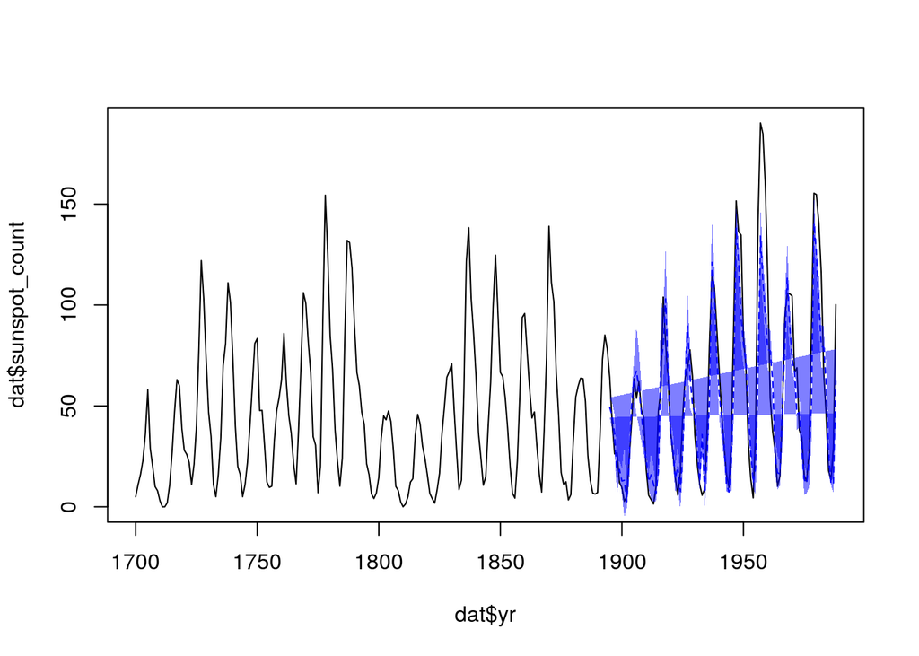

```r
plot(dat$yr, dat$sunspot_count, type = "l")
lines(predictions$time, predictions$pred, col = "blue", lty = 2)
polygon(c(predictions$time, rev(predictions$time)),
        c(predictions$pred - sqrt(predictions$pred_var),
        rev(predictions$pred + sqrt(predictions$pred_var))),
        col = rgb(0, 0, 1, 0.5), border = NA)
```